# Assignment 2

Charles Lang

September 24, 2020

# Part I

## Data Wrangling

In the hackathon a project was proposed to collect data from student video watching, a sample of this data is available in the file video-data.csv.

stid = student id year = year student watched video participation = whether or not the student opened the video watch.time = how long the student watched the video for confusion.points = how many times a student rewatched a section of a video key,points = how many times a student skipped or increased the speed of a video

```r
#Install the 'tidyverse' package or if that does not work, install the 'dplyr' and 'tidyr' packages.

#Load the package(s) you just installed
library(tidyverse)
library(tidyr)
library(dplyr)

D1 <- read.csv("video-data.csv", header = TRUE)

#Create a data frame that only contains the years 2018
D2 <- filter(D1, year == 2018)
```

## Histograms

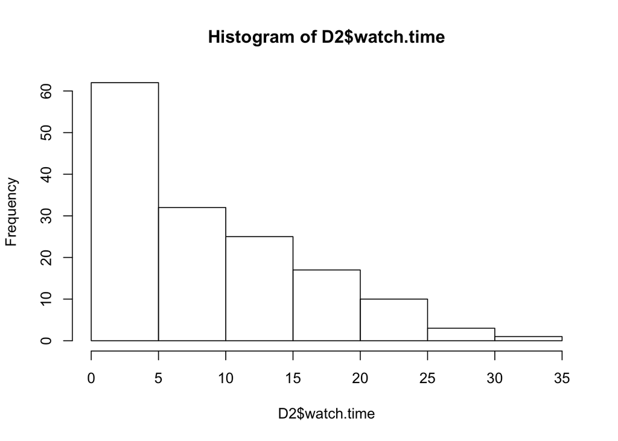

```r
#Generate a histogram of the watch time for the year 2018

hist(D2$watch.time)
```

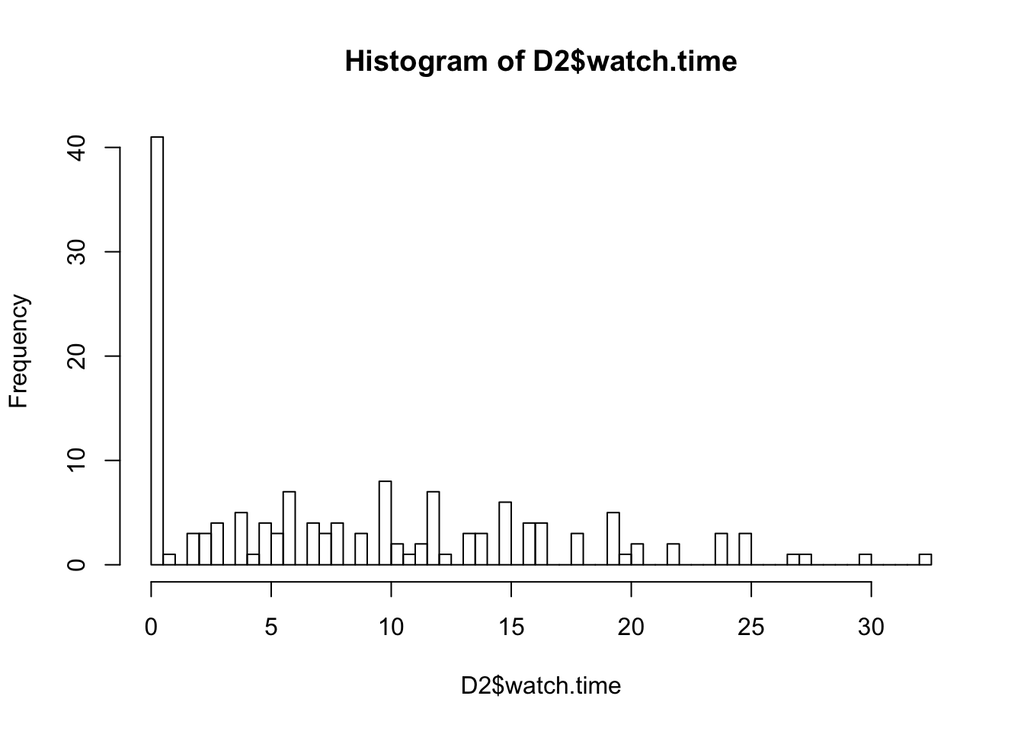

```r
#Change the number of breaks to 100, do you get the same impression?

hist(D2$watch.time, breaks = 100)
```

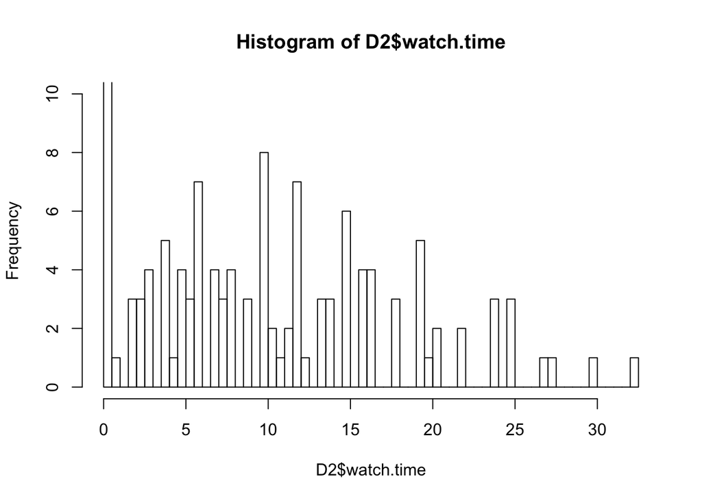

```r
#Cut the y-axis off at 10

hist(D2$watch.time, breaks = 100, ylim = c(0,10))
```

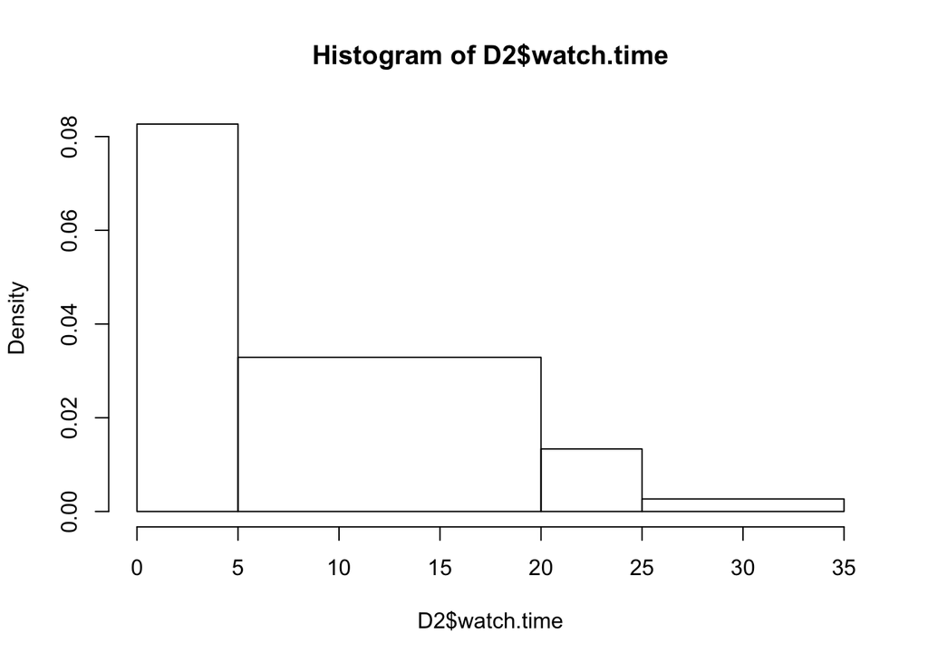

```r
#Restore the y-axis and change the breaks so that they are 0-5, 5-20, 20-25, 25-35

hist(D2$watch.time, breaks = c(0,5,20,25,35))
```

## Plots

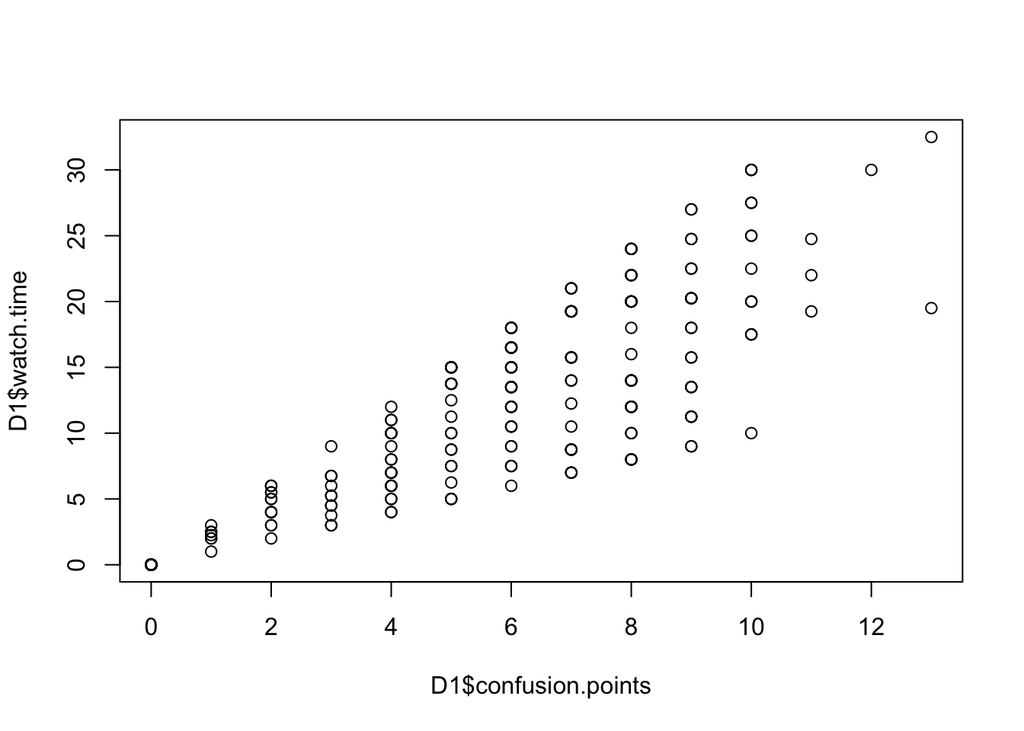

```r
#Plot the number of confusion points against the watch time

plot(D1$confusion.points, D1$watch.time)
```

```r
#Create two variables x & y
x <- c(1,3,2,7,6,4,4)
y <- c(2,4,2,3,2,4,3)

#Create a table from x & y
table1 <- table(x,y)
table1
```

```
##    y
## x   2 3 4
##   1 1 0 0
##   2 1 0 0
##   3 0 0 1
##   4 0 1 1
##   6 1 0 0
##   7 0 1 0
```

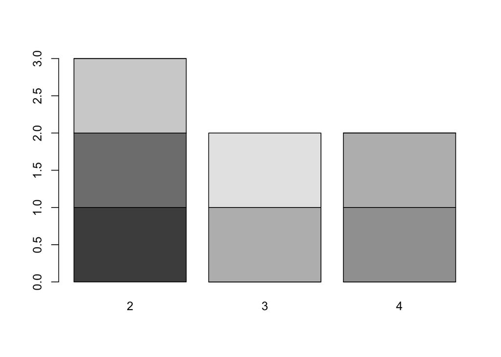

```r
#Display the table as a Barplot
barplot(table1)
```

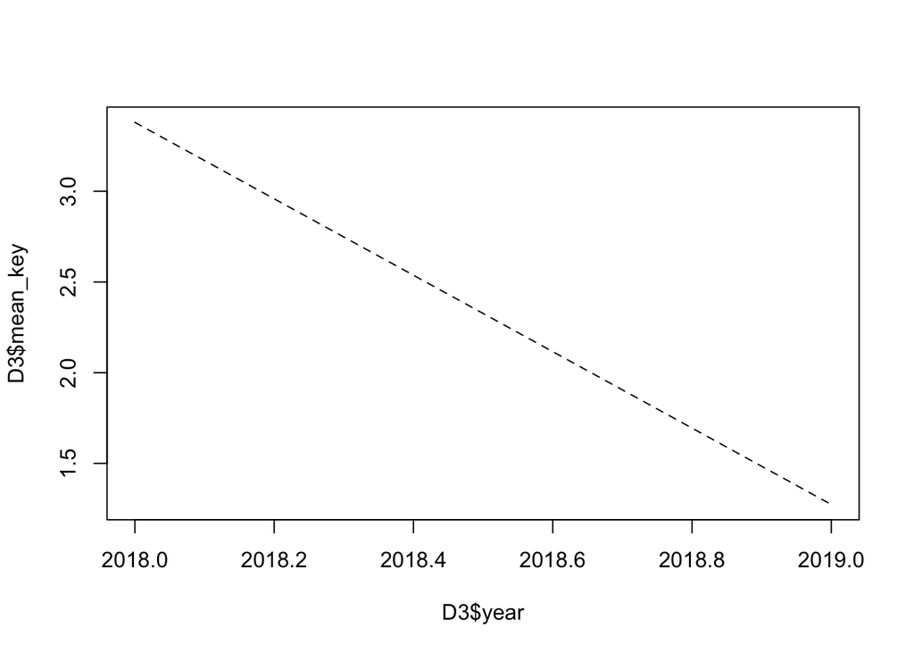

```r
#Create a data frame of the average total key points for each year and plot the two against each other as a lines

D3 <- D1 %>% group_by(year) %>% summarise(mean_key = mean(key.points))
plot(D3$year, D3$mean_key, type = "l", lty = "dashed")
```

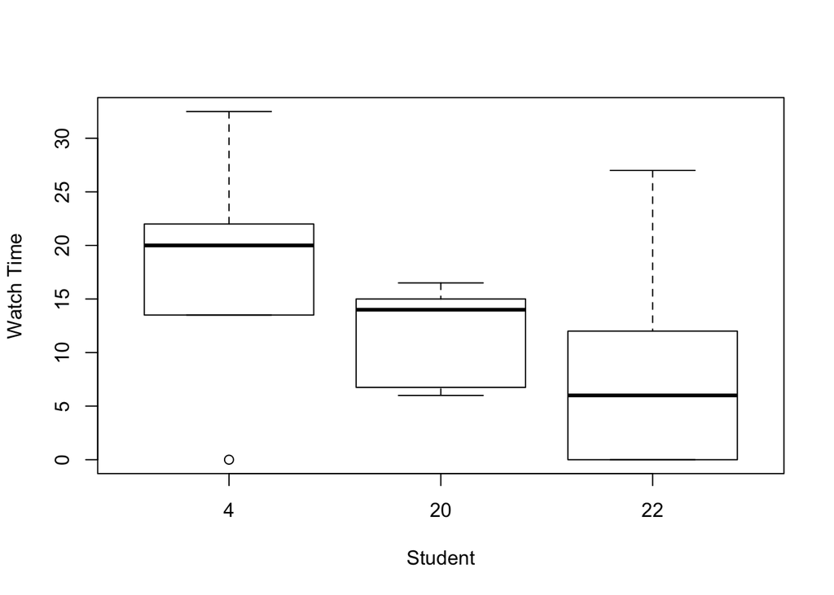

```r
#Create a boxplot of total enrollment for three students
D4 <- filter(D1, stid == 4|stid == 20| stid == 22)
#The drop levels command will remove all the schools from the variable with no data
D4 <- droplevels(D4)
boxplot(D4$watch.time~D4$stid, xlab = "Student", ylab = "Watch Time")
```

## Pairs

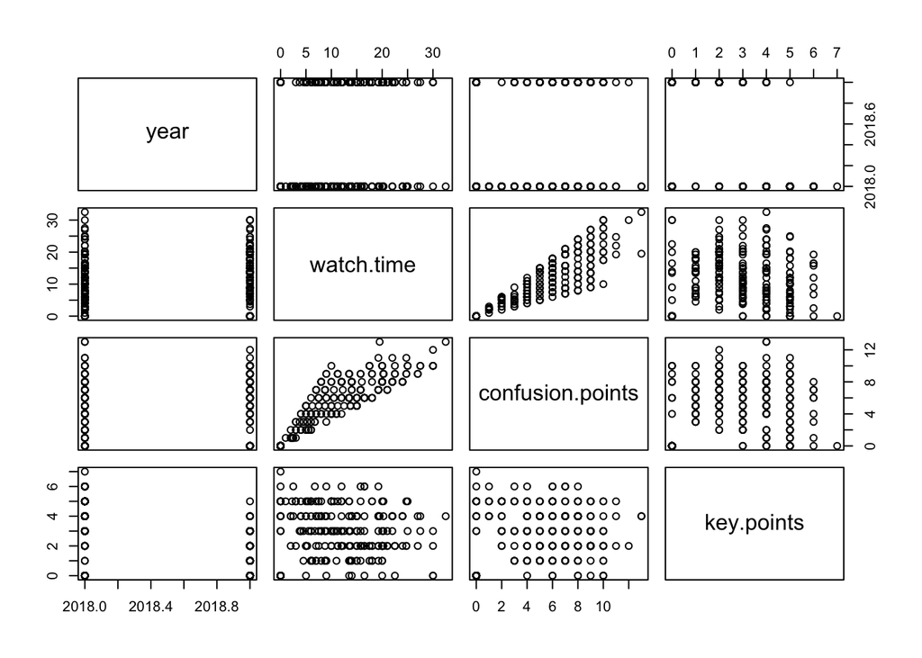

```r
#Use matrix notation to select columns 2, 5, 6, and 7
D5 <- D1[,c(2,5,6,7)]
#Draw a matrix of plots for every combination of variables
pairs(D5)
```

## Part II

1. Create a simulated data set containing 100 students, each with a score from 1-100 representing performance in an educational game. The scores should tend to cluster around 75. Also, each student should be given a classification that reflects one of four interest groups: sport, music, nature, literature.

```r
#rnorm(100, 75, 15) creates a random sample with a mean of 75 and standard deviation of 20
#filter() can be used to set a maximum and minimum value
#round() rounds numbers to whole number values
#sample() draws a random samples from the groups vector according to a uniform distribution


scores <- rnorm(100,75,20)
scores
```

```
##   [1]  67.870332  81.553491 105.186001  83.310104   8.937574  71.665475
##   [7]  83.223851  75.663161 104.083548 100.230645  93.812701  86.406066
##  [13]  52.049380  64.622512  69.795725  91.896714  57.715645  56.572132
##  [19]  80.547229  56.377965  89.337342  70.508777  88.695748  97.567376
##  [25]  79.335555  91.622707  58.597728  66.084734  94.180189  96.540018
##  [31]  60.593159 123.796374  43.220815  56.589467  68.207402  45.008539
##  [37]  90.594179  69.894269  94.755911  63.125921  77.577055  82.672444
##  [43]  99.087739  54.822352 110.403680 101.456573  77.357019  60.353461
##  [49]  43.878797  68.004403  82.717516  82.862034  96.705609  68.249185
##  [55] 109.373286  91.962797  51.975587  50.885796  39.656157 100.978632
##  [61]  57.995017  82.190453  89.981612  68.787316 105.261121  69.490007
##  [67]  74.180417  43.196939  70.967438  67.371648  82.276069  94.015622
##  [73]  84.020755  50.739986  70.778511  74.497836  94.709721  58.783017
##  [79]  74.292326  76.313582  53.368849  93.273167  95.366018  98.401471
##  [85]  57.288857  51.181939  56.260762  94.072126  39.469903  94.382967
##  [91]  39.862963  81.551267  47.347608  60.541881  45.861248  69.624102
##  [97]  77.545416  57.407477  81.082190  87.122194
```

```r
S1 <- data.frame(scores)
S1 <- filter(S1, scores <= 100)
S2 <- data.frame(rep(100,9))
names(S2) <- c("scores")
S3 <- bind_rows(S1,S2)
```

2. Using base R commands, draw a histogram of the scores. Change the breaks in your histogram until you think they best represent your data.

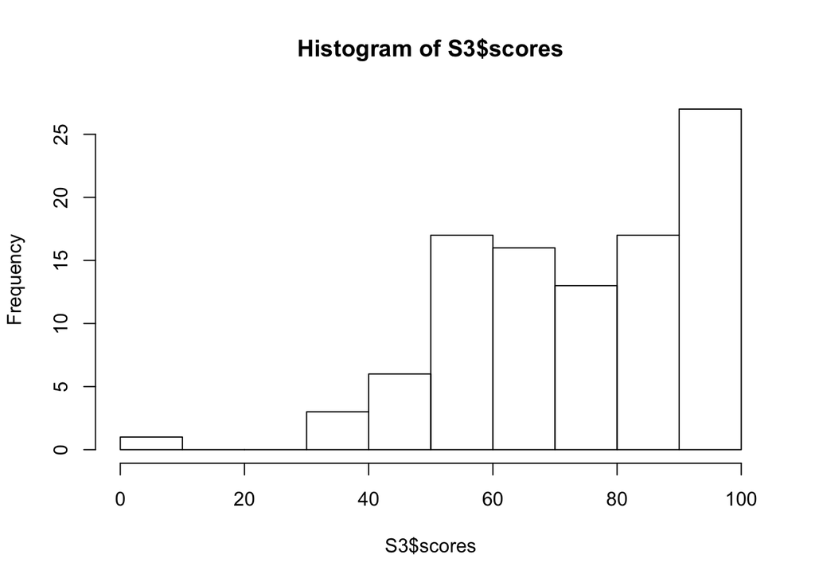

```r
hist(S3$scores, breaks = 10)
```

3. Create a new variable that groups the scores according to the breaks in your histogram.

```r
#cut() divides the range of scores into intervals and codes the values in scores according to which interval they fall. We use a vector called `letters` as the labels, `letters` is a vector made up of the letters of the alphabet.
label <- letters[1:10]
S3$breaks <- cut(S3$scores, breaks = 10, labels = label)
```

4. Now using the colorbrewer package (RColorBrewer; http://colorbrewer2.org/#type=sequential&scheme=BuGn&n=3) design a pallette and assign it to the groups in your data on the histogram.

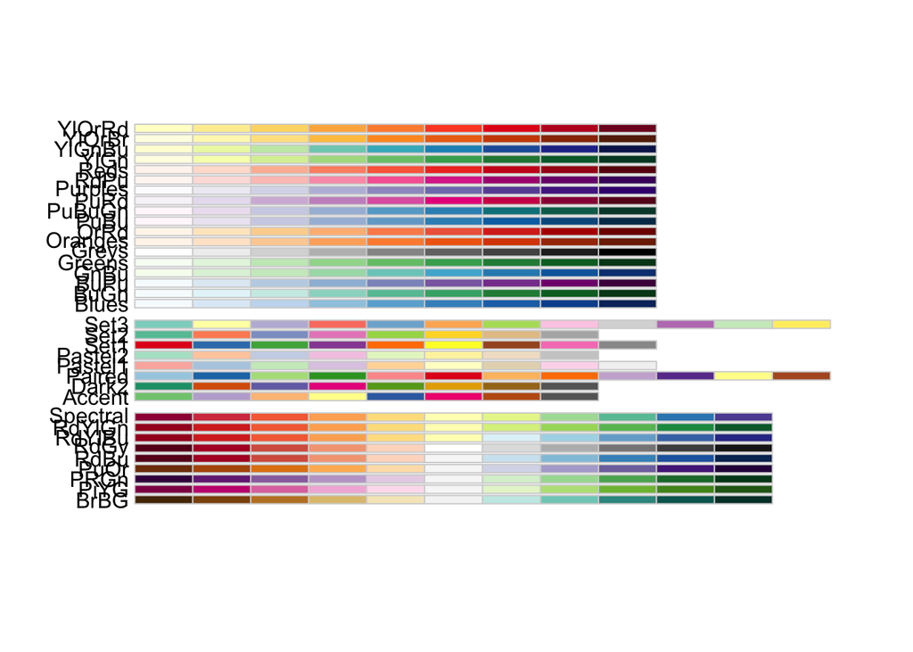

```r
library(RColorBrewer)

display.brewer.all()
```

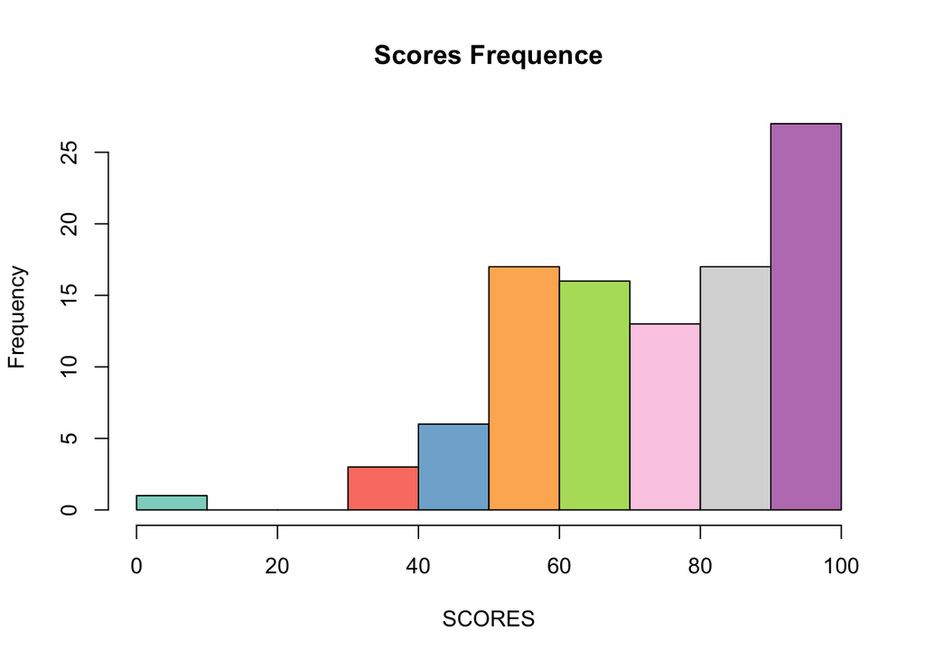

```r
#The top section of palettes are sequential, the middle section are qualitative, and the lower section are diverging.
#Make RColorBrewer palette available to R and assign to your bins
S3$colors <- brewer.pal(10,"Set3")

#Use named palette in histogram
hist(S3$scores, col = S3$colors,xlab="SCORES",main = "Scores Frequence")
```

5. Create a boxplot that visualizes the scores for each interest group and color each interest group a different color.

```r
#Make a vector of the colors from RColorBrewer

interest <- c('Sport', 'Music', 'Nature', 'literature')
S3$interest <- sample(interest,100,replace = TRUE)
sample(interest,100,replace = TRUE)
```

```
##   [1] "Sport"      "Music"      "Nature"     "literature" "literature"
##   [6] "Sport"      "Sport"      "Sport"      "literature" "literature"
##  [11] "literature" "Sport"      "Nature"     "literature" "literature"
##  [16] "Nature"     "Nature"     "literature" "literature" "Music"
##  [21] "Nature"     "Music"      "Music"      "literature" "Nature"
##  [26] "Sport"      "Music"      "Music"      "Nature"     "literature"
##  [31] "Sport"      "Nature"     "Nature"     "Sport"      "Nature"
##  [36] "Sport"      "Music"      "Music"      "Sport"      "literature"
##  [41] "literature" "Music"      "Sport"      "Music"      "literature"
##  [46] "literature" "Music"      "literature" "Music"      "Music"
##  [51] "Nature"     "Nature"     "Music"      "Music"      "literature"
##  [56] "Music"      "Music"      "literature" "literature" "Music"
##  [61] "Music"      "literature" "Sport"      "Sport"      "Sport"
##  [66] "literature" "Music"      "Music"      "literature" "Sport"
##  [71] "literature" "Nature"     "Sport"      "Music"      "Sport"
##  [76] "Nature"     "Sport"      "Sport"      "literature" "Music"
##  [81] "Sport"      "Nature"     "Music"      "Nature"     "Music"
##  [86] "Nature"     "Sport"      "literature" "Nature"     "Music"
##  [91] "Music"      "Nature"     "Music"      "literature" "Sport"
##  [96] "Nature"     "Nature"     "Nature"     "Music"      "literature"
```

```r
S3$stid <- seq(1,100,1)

interest.col <- brewer.pal(4,'Dark2')

interest.col
```

```
## [1] "#1B9E77" "#D95F02" "#7570B3" "#E7298A"
```

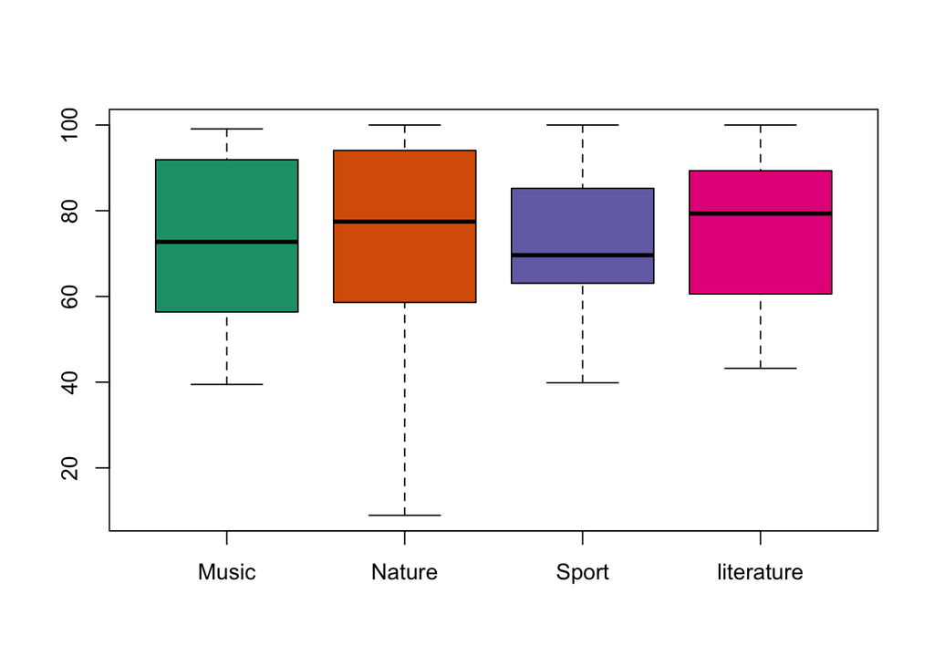

```r
boxplot(S3$scores~S3$interest,col = interest.col)
```

6. Now simulate a new variable that describes the number of logins that students made to the educational game. They should vary from 1-25.

```r
logins <- sample(seq(1,25,1), 100, replace = TRUE)
S3$login <- logins
```

7. Plot the relationships between logins and scores. Give the plot a title and color the dots according to interest group.

[figure not shown]

```
##   xchar= 0.675 ; (yextra,ychar)= 0 6.225
##   rect2(21.35,36.42, w=4.605, h=31.12, ...)
##   points2( 22.03 22.03 22.03 22.03 , 30.19 23.97 17.74 11.52 , pch= 19 19 19 19 , ...)
```

```r
S3$interestColor <- factor(S3$interest)
levels(S3$interestColor) <- interest.col
S3$interestColor <- as.character(S3$interestColor)
plot(S3$login, S3$scores, col = S3$interestColor,pch=19,xlab = "Login times", ylab =
       "Scores", main = "Scores VS Login times")
legend(
  "bottomright",legend = levels(factor(S3$interest)), col = levels(factor(S3$interestColor)), pch=19,trace=TRUE
)
```

8. R contains several inbuilt data sets, one of these in called AirPassengers. Plot a line graph of the the airline passengers over time using this data set.

```r
data("AirPassengers")
airPassengersData <- AirPassengers
class(airPassengersData)
```

```
## [1] "ts"
```

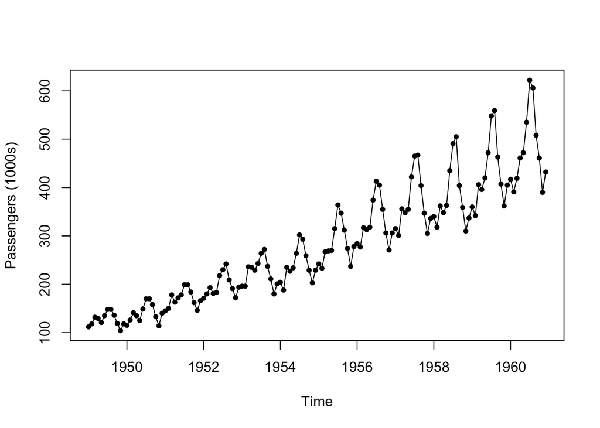

```r
plot(airPassengersData, ylab="Passengers (1000s)", type="o", pch =20)
```

```r
airPassengersData
```

```
##      Jan Feb Mar Apr May Jun Jul Aug Sep Oct Nov Dec
## 1949 112 118 132 129 121 135 148 148 136 119 104 118
## 1950 115 126 141 135 125 149 170 170 158 133 114 140
## 1951 145 150 178 163 172 178 199 199 184 162 146 166
## 1952 171 180 193 181 183 218 230 242 209 191 172 194
## 1953 196 196 236 235 229 243 264 272 237 211 180 201
## 1954 204 188 235 227 234 264 302 293 259 229 203 229
## 1955 242 233 267 269 270 315 364 347 312 274 237 278
## 1956 284 277 317 313 318 374 413 405 355 306 271 306
## 1957 315 301 356 348 355 422 465 467 404 347 305 336
## 1958 340 318 362 348 363 435 491 505 404 359 310 337
## 1959 360 342 406 396 420 472 548 559 463 407 362 405
## 1960 417 391 419 461 472 535 622 606 508 461 390 432
```

9. Using another inbuilt data set, iris, plot the relationships between all of the variables in the data set. Which of these relationships is it appropraiet to run a correlation on?

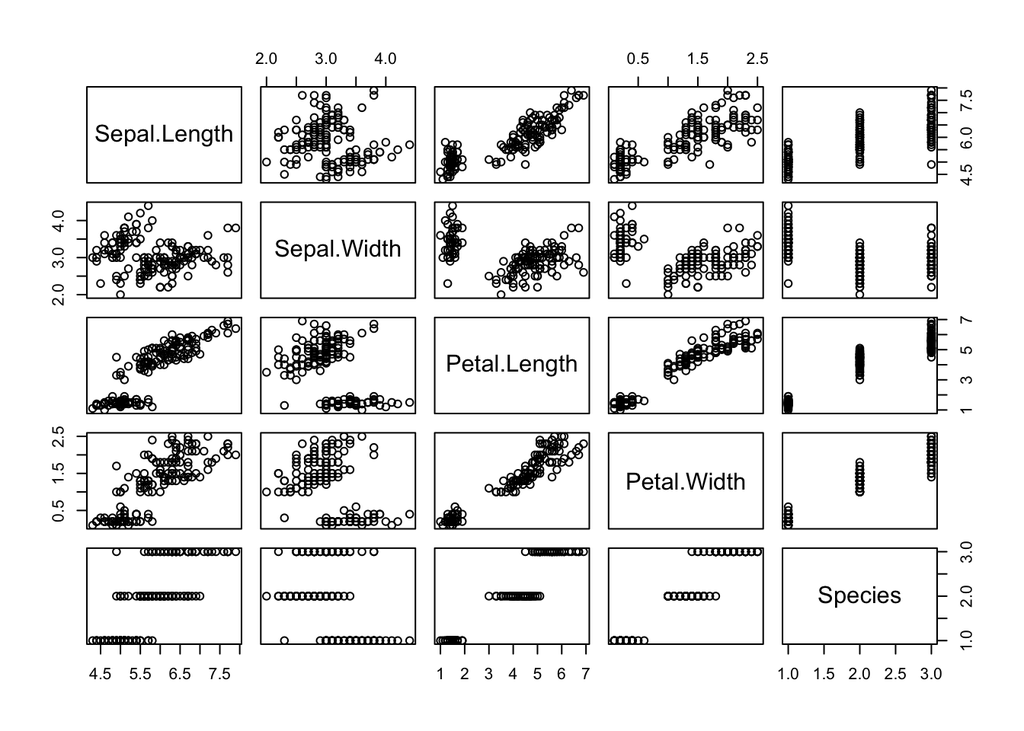

```r
data('iris')
iris.data <- iris
pairs(iris.data)
```

# Part III - Analyzing Swirl

## Data

In this repository you will find data describing Swirl activity from the class so far this semester. Please connect RStudio to this repository.

### Instructions

1. Insert a new code block
2. Create a data frame from the `swirl-data.csv` file called `DF1`

```r
DF1 <- read.csv(file = 'swirl-data.csv')
```

The variables are:

`course_name` - the name of the R course the student attempted  
`lesson_name` - the lesson name  
`question_number` - the question number attempted `correct` - whether the question was answered correctly  
`attempt` - how many times the student attempted the question  
`skipped` - whether the student skipped the question  
`datetime` - the date and time the student attempted the question  
`hash` - anonymyzed student ID

3. Create a new data frame that only includes the variables `hash`, `lesson_name` and `attempt` called `DF2`

```r
DF2 <- data.frame(
  hash = DF1$hash,
  lesson_name = DF1$lesson_name,
  attempt = DF1$attempt
  )
```

4. Use the `group_by` function to create a data frame that sums all the attempts for each `hash` by each `lesson_name` called `DF3`

```r
DF3 <- DF2 %>% group_by(lesson_name,hash) %>% summarise(TotalAttempt = sum(attempt, na.rm = TRUE))
```

5. On a scrap piece of paper draw what you think `DF3` would look like if all the lesson names were column names
6. Convert `DF3` to this format

```r
DF3 <- t(DF3)
```

7. Create a new data frame from `DF1` called `DF4` that only includes the variables `hash`, `lesson_name` and `correct`

```r
DF4 <- data.frame(
  hash = DF1$hash,
  lesson_name = DF1$lesson_name,
  correct = DF1$correct
  )
```

8. Convert the `correct` variable so that `TRUE` is coded as the **number** `1` and `FALSE` is coded as `0`

```r
DF4$correct <- as.integer(DF4$correct)
DF4$correct <- ifelse(DF4$correct == TRUE, 1, 0)
```

9. Create a new data frame called `DF5` that provides a mean score for each student on each course

```r
DF5 <- DF4 %>% group_by(lesson_name,hash) %>% summarise(Mean = mean(correct, na.rm = TRUE))
```

10. **Extra credit** Convert the `datetime` variable into month-day-year format and create a new data frame (`DF6`) that shows the average correct for each day

Finally use the knitr function to generate an html document from your work. Commit, Push and Pull Request your work back to the main branch of the repository. Make sure you include both the .Rmd file and the .html file.